# Yuqi_EDA

Yuqi Miao ym2771

4/13/2022

# 0 Data explore

## Descriptive table

| **Characteristic** | **censored**, N = 305<sup>1</sup> | **complete**, N = 75<sup>1</sup> | **p-value**<sup>2</sup> |
| --- | --- | --- | --- |
| intake_age | 46.85 (45.55, 48.59) | 49.45 (47.82, 51.75) | <0.001 |
| menopause_age | 50.81 (49.64, 52.69) | 51.89 (49.86, 53.55) | 0.041 |
| race |  |  | 0.042 |
| white | 248 (81%) | 56 (75%) |  |
| black | 24 (7.9%) | 13 (17%) |  |
| other | 33 (11%) | 6 (8.0%) |  |
| education |  |  | 0.7 |
| post graduate | 132 (43%) | 35 (47%) |  |
| college graduate | 81 (27%) | 15 (20%) |  |
| some college | 54 (18%) | 16 (21%) |  |
| high school or less | 38 (12%) | 9 (12%) |  |
| menopause_time | 4.38 (3.18, 4.75) | 1.94 (1.20, 3.20) | <0.001 |

<sup>*1*</sup> Median (IQR); n (%) <sup>*2*</sup> Wilcoxon rank sum test; Pearson's Chi-squared test

```
##
## Call:
## glm(formula = menopause ~ intake_age + race + education, family = "binomial",
##     data = data)
##
## Deviance Residuals:
##     Min       1Q   Median       3Q      Max
## -1.9363  -0.6197  -0.4532  -0.3106   2.4138
##
## Coefficients:
##                               Estimate Std. Error z value Pr(>|z|)
## (Intercept)                  -17.32972    2.53205  -6.844 7.69e-12 ***
## intake_age                     0.33145    0.05190   6.386 1.70e-10 ***
## raceblack                      1.11473    0.44112   2.527   0.0115 *
## raceother                     -0.28683    0.51013  -0.562   0.5739
## educationcollege graduate     -0.70943    0.37940  -1.870   0.0615 .
## educationsome college         -0.00714    0.37872  -0.019   0.9850
## educationhigh school or less  -0.65747    0.49456  -1.329   0.1837
## ---
## Signif. codes:  0 '***' 0.001 '**' 0.01 '*' 0.05 '.' 0.1 ' ' 1
##
## (Dispersion parameter for binomial family taken to be 1)
##
##     Null deviance: 377.52  on 379  degrees of freedom
## Residual deviance: 323.37  on 373  degrees of freedom
## AIC: 337.37
##
## Number of Fisher Scoring iterations: 5
```

- The larger the intake age, the more likely the menopause happend during the study time
- Censoring is more likely to happen when the intake age is small, indicating the insufficient study time for subjects starts early to reach event.
- Should be common in the study?

[narr] For survival age onset as event, there are 2 starting points can be considered: first is the follow up time or time on study; Second is the time at birth;

## Plot the survival time

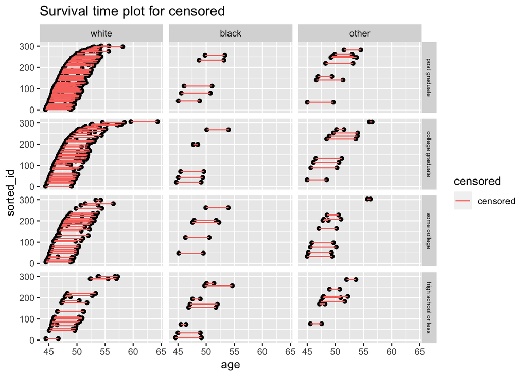

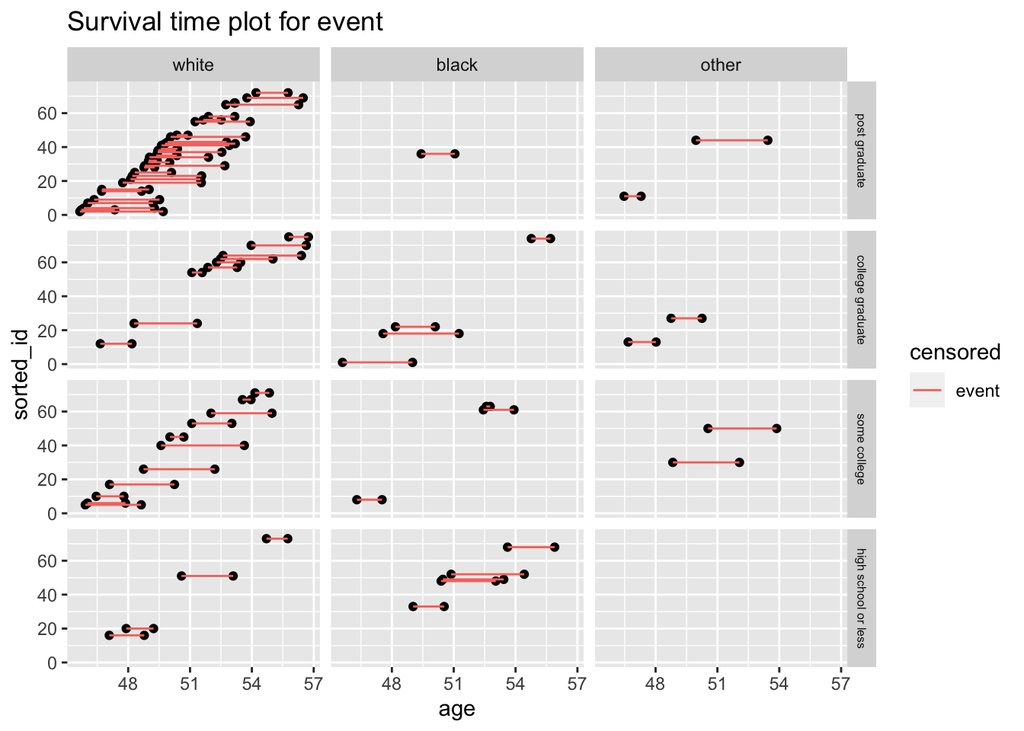

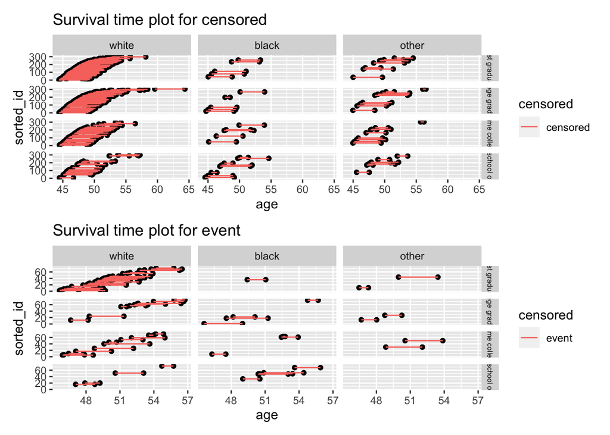

- Clearly, the people intake with older age are more likely to be in the event group

# I. [RT]Starting at Recruitment time: survival on meno_time

## exponential

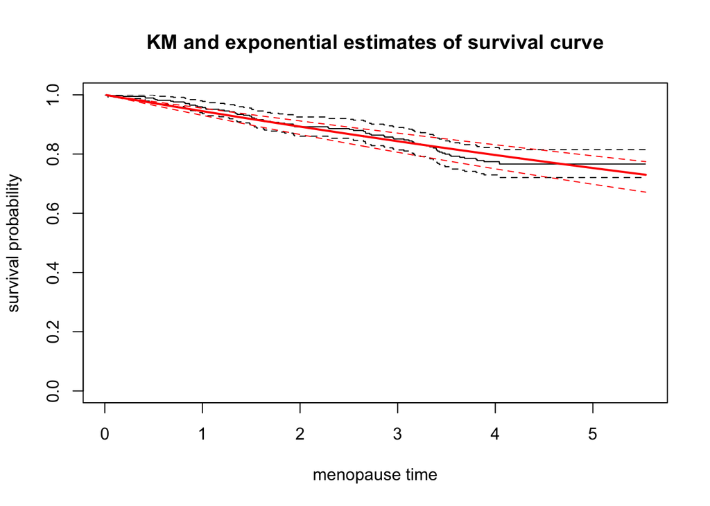

```
##
##   quantile      est      lcl      ucl
## 1      0.5 12.20225 9.719324 15.20633
```

**TODO** plot separately? **TODO** how did the function estimate the CI?

## KM

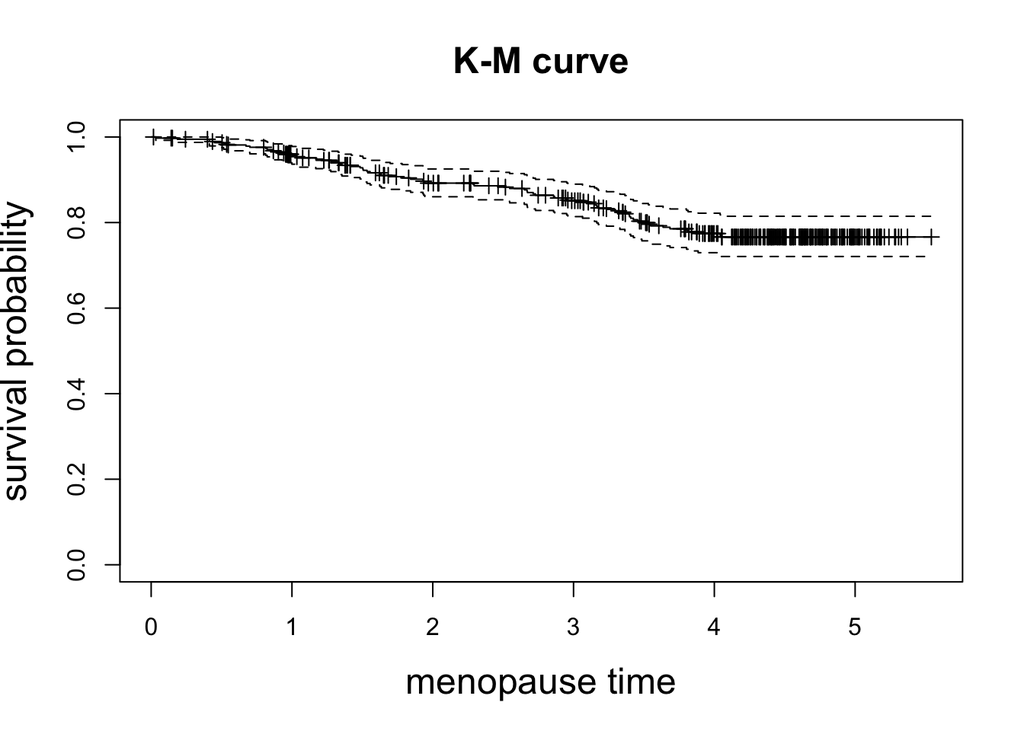

```
## Call: survfit(formula = Surv(menopause_time, menopause) ~ 1, data = data,
##     conf.type = "log")
##
##    time n.risk n.event survival std.err lower 95% CI upper 95% CI
##  0.0329    379       1    0.997 0.00264        0.992        1.000
##  0.1862    376       1    0.995 0.00373        0.987        1.000
##  0.4134    373       2    0.989 0.00528        0.979        1.000
##  0.5010    370       1    0.987 0.00591        0.975        0.998
##  0.5147    368       1    0.984 0.00647        0.971        0.997
##  0.5366    367       1    0.981 0.00699        0.968        0.995
##  0.6735    364       1    0.979 0.00747        0.964        0.993
##  0.7009    363       1    0.976 0.00792        0.961        0.992
##  0.8131    361       1    0.973 0.00835        0.957        0.990
##  0.8241    360       1    0.971 0.00875        0.954        0.988
##  0.8679    359       2    0.965 0.00950        0.947        0.984
##  0.9309    355       1    0.962 0.00986        0.943        0.982
##  0.9500    353       1    0.960 0.01020        0.940        0.980
##  0.9993    339       1    0.957 0.01055        0.936        0.978
##  1.0322    338       1    0.954 0.01090        0.933        0.976
##  1.0376    336       1    0.951 0.01123        0.929        0.973
##  1.1691    333       1    0.948 0.01155        0.926        0.971
##  1.2238    332       1    0.945 0.01186        0.923        0.969
##  1.2758    328       1    0.943 0.01217        0.919        0.967
##  1.3279    327       1    0.940 0.01247        0.916        0.964
##  1.3415    324       1    0.937 0.01277        0.912        0.962
##  1.3552    323       1    0.934 0.01305        0.909        0.960
##  1.4209    317       1    0.931 0.01334        0.905        0.957
##  1.4839    316       1    0.928 0.01362        0.902        0.955
##  1.5031    315       1    0.925 0.01389        0.898        0.953
##  1.5058    314       1    0.922 0.01416        0.895        0.950
##  1.5332    313       1    0.919 0.01441        0.891        0.948
##  1.5551    312       1    0.916 0.01467        0.888        0.945
##  1.6235    309       1    0.913 0.01491        0.884        0.943
##  1.6345    308       1    0.910 0.01516        0.881        0.941
##  1.6975    303       1    0.907 0.01540        0.878        0.938
##  1.7823    301       1    0.904 0.01564        0.874        0.935
##  1.8426    299       1    0.901 0.01588        0.871        0.933
##  1.9302    298       1    0.898 0.01611        0.867        0.930
##  1.9357    297       1    0.895 0.01634        0.864        0.928
##  1.9439    295       1    0.892 0.01656        0.860        0.925
```

[output cut: 22 more lines]

```
##  3.3949    236       1    0.817 0.02134        0.776        0.860
##  3.3977    235       1    0.814 0.02153        0.772        0.857
##  3.4059    234       1    0.810 0.02172        0.769        0.854
##  3.4251    233       1    0.807 0.02190        0.765        0.851
##  3.4552    232       1    0.803 0.02208        0.761        0.848
##  3.4853    229       1    0.800 0.02226        0.757        0.845
##  3.5318    225       1    0.796 0.02244        0.753        0.841
##  3.5455    223       1    0.793 0.02263        0.749        0.838
##  3.6359    221       1    0.789 0.02281        0.745        0.835
##  3.6851    220       1    0.785 0.02298        0.742        0.832
##  3.8029    215       1    0.782 0.02316        0.738        0.828
##  3.8138    214       1    0.778 0.02334        0.734        0.825
##  3.8850    208       1    0.774 0.02353        0.730        0.822
##  4.0411    191       1    0.770 0.02375        0.725        0.818
##  4.0438    190       1    0.766 0.02397        0.721        0.815
```

```
## Call: survfit(formula = Surv(menopause_time, menopause) ~ 1, data = data,
##     conf.type = "log")
##
##       n  events  median 0.95LCL 0.95UCL
##     380      75      NA      NA      NA
```

## comparison

- From the KM curve, we can see until the end of the study, the overal survival rate is above 0.5, generating a NA estimation of median survival time;
- When specify the model parametricly, the median survival time can always be estimated;

## cox ph

```
## Call:
## coxph(formula = Surv(menopause_time, menopause) ~ race + education +
##     intake_age, data = data)
##
##   n= 380, number of events= 75
##
##                                  coef exp(coef) se(coef)      z Pr(>|z|)
## raceblack                     0.90155   2.46343  0.33129  2.721   0.0065 **
## raceother                     0.01639   1.01653  0.43332  0.038   0.9698
## educationcollege graduate    -0.88633   0.41217  0.33881 -2.616   0.0089 **
## educationsome college         0.05357   1.05503  0.30769  0.174   0.8618
## educationhigh school or less -0.58824   0.55530  0.40087 -1.467   0.1423
## intake_age                    0.31054   1.36417  0.03647  8.514   <2e-16 ***
## ---
## Signif. codes:  0 '***' 0.001 '**' 0.01 '*' 0.05 '.' 0.1 ' ' 1
##
##                              exp(coef) exp(-coef) lower .95 upper .95
## raceblack                       2.4634     0.4059    1.2869    4.7155
## raceother                       1.0165     0.9837    0.4348    2.3766
## educationcollege graduate       0.4122     2.4262    0.2122    0.8007
## educationsome college           1.0550     0.9478    0.5772    1.9283
## educationhigh school or less    0.5553     1.8008    0.2531    1.2183
## intake_age                      1.3642     0.7330    1.2700    1.4653
##
## Concordance= 0.772  (se = 0.026 )
## Likelihood ratio test= 68.84  on 6 df,   p=7e-13
## Wald test            = 77.65  on 6 df,   p=1e-14
## Score (logrank) test = 86.61  on 6 df,   p=<2e-16
```

- Interpretation:
  - Race
  - Education
- Here the menopause age is linearly dependent to the intake_age, this is greatly reasonable, since at the intake age, no subject is having a menopause. The subject with higher intake age are not at risk at their own intake age, but the subject with lower intake age will be at risk at those age different period.
- For example, if 1 person has intake age 49, then she will definitely have menopause_age > 49, but menopause_age $\neq$ 49 , but for the subject intake with age 45, she will be at risk at age 49;

# II. [TB] Starting at birth: Study on meno_age

[narr] In this study, only the women with no menopause at the recruitment time are chosen in the model, which means those who has menopause before the threshold is not selected, which will cause bias. This forms a left-truncated and right-censored(LTRC) data.

Here, the intake_age is regarded as the left-truncated time.

## lm verification for quasi-independence

```
##
## Call:
## lm(formula = menopause_age ~ race + education + intake_age, data = subset(data,
##     menopause == 1))
##
## Residuals:
##     Min      1Q  Median      3Q     Max
## -1.8613 -0.9718 -0.1301  0.9972  2.0211
##
## Coefficients:
##                               Estimate Std. Error t value Pr(>|t|)
## (Intercept)                   7.821273   2.600574   3.008  0.00369 **
## raceblack                    -0.005866   0.396433  -0.015  0.98824
## raceother                     0.041876   0.505993   0.083  0.93428
## educationcollege graduate    -0.084675   0.377270  -0.224  0.82309
## educationsome college        -0.154693   0.356078  -0.434  0.66535
## educationhigh school or less  0.067962   0.481678   0.141  0.88821
## intake_age                    0.886790   0.052606  16.857  < 2e-16 ***
## ---
## Signif. codes:  0 '***' 0.001 '**' 0.01 '*' 0.05 '.' 0.1 ' ' 1
##
## Residual standard error: 1.147 on 68 degrees of freedom
## Multiple R-squared:  0.8171, Adjusted R-squared:  0.801
## F-statistic: 50.64 on 6 and 68 DF,  p-value: < 2.2e-16
```

[Discussion] * In the problem, the quasi-independent is assumed. This independence implies the intake age should be irrelavant to the menopause age given the covariates when using the age onset as the outcome; * But here in our data, a clear linear relationship between intake age and menopause time;

## survival curve

### exponential

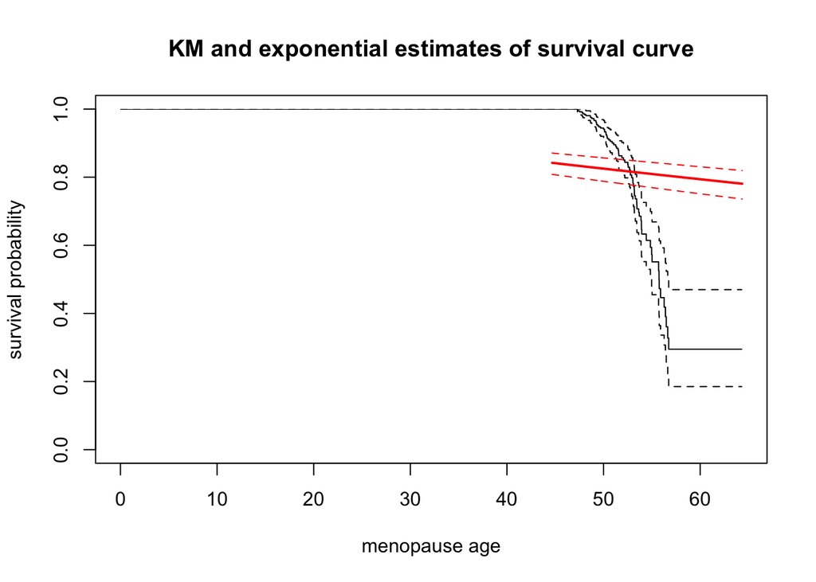

```
##
##   quantile      est      lcl      ucl
## 1      0.5 180.2493 141.5982 227.0728
```

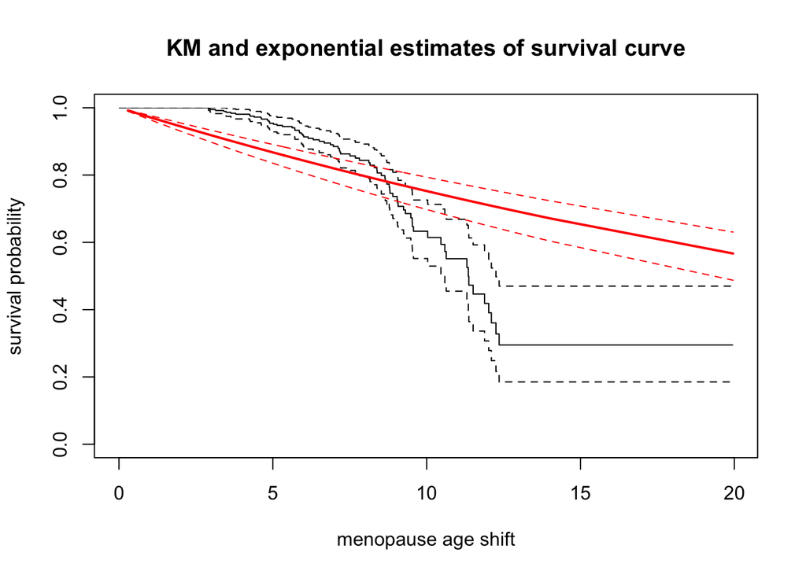

```
## [1] 68.75400 63.77785 75.26924
```

### KM

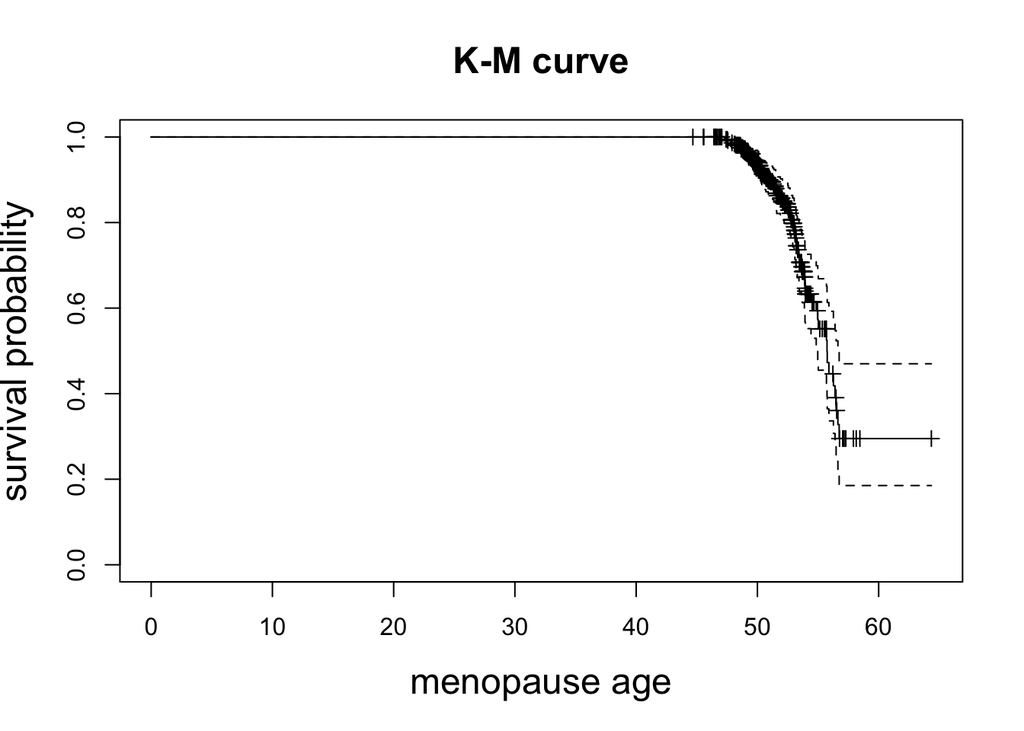

```
## Call: survfit(formula = Surv(menopause_age, menopause) ~ 1, data = data,
##     conf.type = "log")
##
##  time n.risk n.event survival std.err lower 95% CI upper 95% CI
##    44    380       0    1.000 0.00000        1.000        1.000
##    45    379       0    1.000 0.00000        1.000        1.000
##    46    377       0    1.000 0.00000        1.000        1.000
##    47    368       0    1.000 0.00000        1.000        1.000
##    48    358       5    0.986 0.00608        0.974        0.998
##    49    329       5    0.972 0.00866        0.955        0.989
##    50    257       9    0.944 0.01250        0.920        0.969
##    51    185      11    0.900 0.01762        0.866        0.935
##    52    137       8    0.857 0.02251        0.814        0.902
##    53     97       8    0.798 0.02900        0.743        0.857
##    54     43      16    0.633 0.04420        0.552        0.726
##    55     27       3    0.573 0.05198        0.479        0.684
##    56     17       5    0.446 0.06449        0.336        0.593
##    57      8       5    0.295 0.07007        0.185        0.470
##    58      3       0    0.295 0.07007        0.185        0.470
##    59      1       0    0.295 0.07007        0.185        0.470
##    60      1       0    0.295 0.07007        0.185        0.470
```

```
## Call: survfit(formula = Surv(menopause_age, menopause) ~ 1, data = data,
##     conf.type = "log")
##
##       n  events  median 0.95LCL 0.95UCL
##   380.0    75.0    55.7    55.0    56.6
```

Compare 2 summary table

[output not shown]

```
## Call: survfit(formula = Surv(menopause_age, menopause) ~ 1, data = data,
##     conf.type = "log")
##
##  time n.risk n.event survival std.err lower 95% CI upper 95% CI
##    44    380       0    1.000 0.00000        1.000        1.000
##    45    379       0    1.000 0.00000        1.000        1.000
##    46    377       0    1.000 0.00000        1.000        1.000
##    47    368       0    1.000 0.00000        1.000        1.000
##    48    358       5    0.986 0.00608        0.974        0.998
##    49    329       5    0.972 0.00866        0.955        0.989
##    50    257       9    0.944 0.01250        0.920        0.969
##    51    185      11    0.900 0.01762        0.866        0.935
##    52    137       8    0.857 0.02251        0.814        0.902
##    53     97       8    0.798 0.02900        0.743        0.857
##    54     43      16    0.633 0.04420        0.552        0.726
##    55     27       3    0.573 0.05198        0.479        0.684
##    56     17       5    0.446 0.06449        0.336        0.593
##    57      8       5    0.295 0.07007        0.185        0.470
##    58      3       0    0.295 0.07007        0.185        0.470
##    59      1       0    0.295 0.07007        0.185        0.470
##    60      1       0    0.295 0.07007        0.185        0.470
```

## Race

### PH model with only race

For difference of survival among risk

```
## Call:
## coxph(formula = Surv(time = intake_age, time2 = menopause_age,
##     event = menopause) ~ race, data = data)
##
##   n= 380, number of events= 75
##
##              coef exp(coef) se(coef)      z Pr(>|z|)
## raceblack  0.7636    2.1460   0.3118  2.449   0.0143 *
## raceother -0.1026    0.9025   0.4325 -0.237   0.8125
## ---
## Signif. codes:  0 '***' 0.001 '**' 0.01 '*' 0.05 '.' 0.1 ' ' 1
##
##           exp(coef) exp(-coef) lower .95 upper .95
## raceblack    2.1460      0.466    1.1647     3.954
## raceother    0.9025      1.108    0.3866     2.107
##
## Concordance= 0.537  (se = 0.029 )
## Likelihood ratio test= 5.4  on 2 df,   p=0.07
## Wald test            = 6.35  on 2 df,   p=0.04
## Score (logrank) test = 6.67  on 2 df,   p=0.04
```

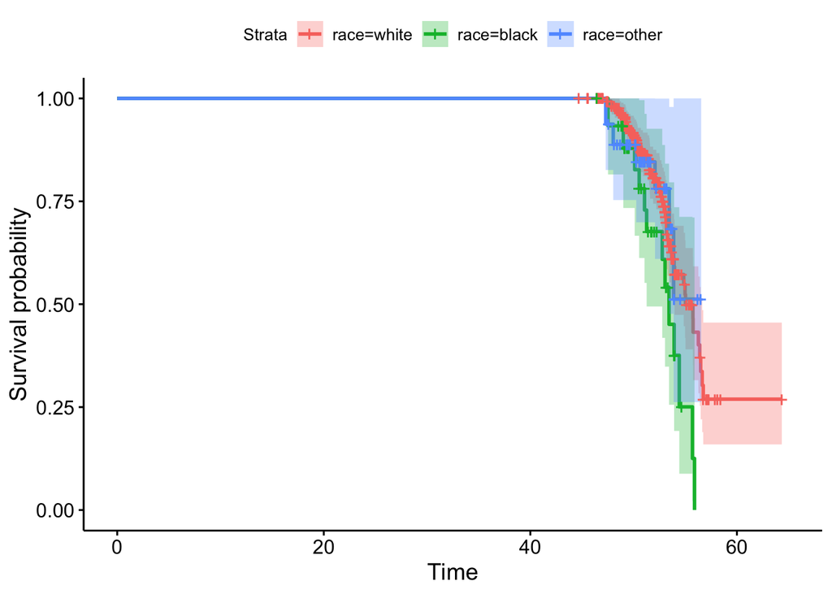

- Overall is siginificant as in the logrank test res: Score (logrank) test = 6.67 on 2 df, p=0.04
- There is significant difference of the menopause age between black and white,
- No significant difference between other and white
- Calculate the coefficient and significance between black and others
  - Here, just change the reference group [Question] How to get the fisher information from coxPH?

[output not shown]

### PH model for additional contribution

$$\begin{aligned}
h_i(t) &= h_0(t)exp(\eta_i)\\
\eta_i&=\beta_1I(race=black)_i\\
&+\beta_2I(race=others)_i\\
&+\beta_3I(education=college graduate)_i\\
&+\beta_4I(education=some college)_i\\
&+\beta_5I(education=high school or less)_i
\end{aligned}$$

[Discuss]

- How to express the left truncation part in the model?
- point and 95% confidence interval estimates for the relative risk of menopause_age for a Black Patient with an Other Ethnicity patient controlling for education.

```
##  exp(coef) exp(-coef)  lower .95  upper .95
##  2.6404576  0.3787222  0.9826997  7.0947579
```

- For subject i, black and subject k, others, with the same education

$$HR(t) = \frac{h_i(t)}{h_k(t)}=exp(\beta_1-\beta_2)$$
* Interpretation:

Conditioning on the same education level and survival beyond t, the probability that subject i is menopause at time t is 2.64 times the probability that subject k is menopaused at time t

- an estimate of the baseline survival function for White non-Hispanic patients with Post- graduate education

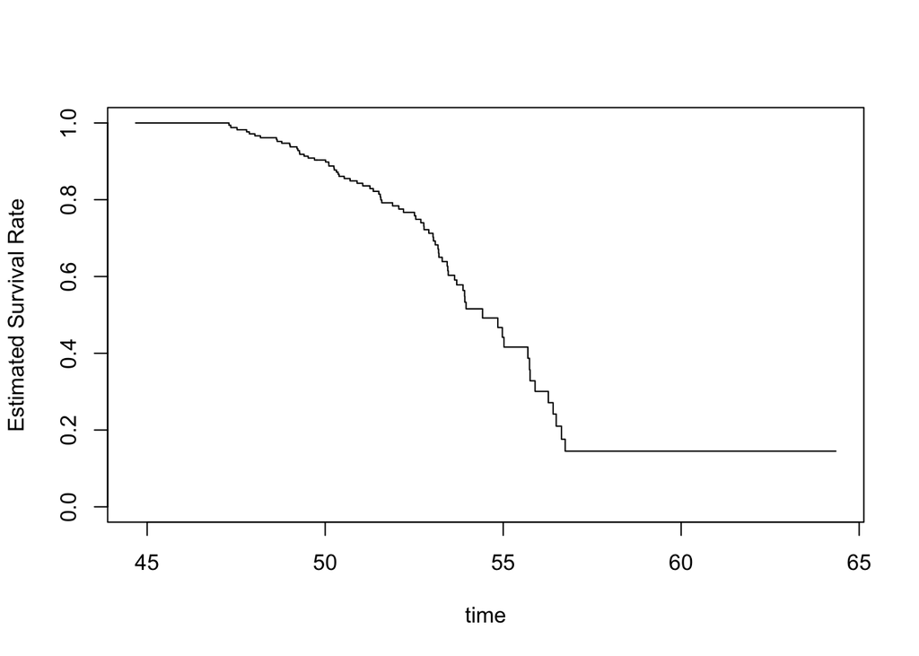

- Check your model assumptions
  - Reference: Kleinbaum and Klein, Survival Analysis.
  - 3 ways:
    - Graphical,
    - GOF,
    - time-dependent variable
  - Reference: https://www.emilyzabor.com/tutorials/survival_analysis_in_r_tutorial.html#Assessing_proportional_hazards

```
##           chisq df    p
## race      1.869  2 0.39
## education 0.924  3 0.82
## GLOBAL    3.165  5 0.67
```

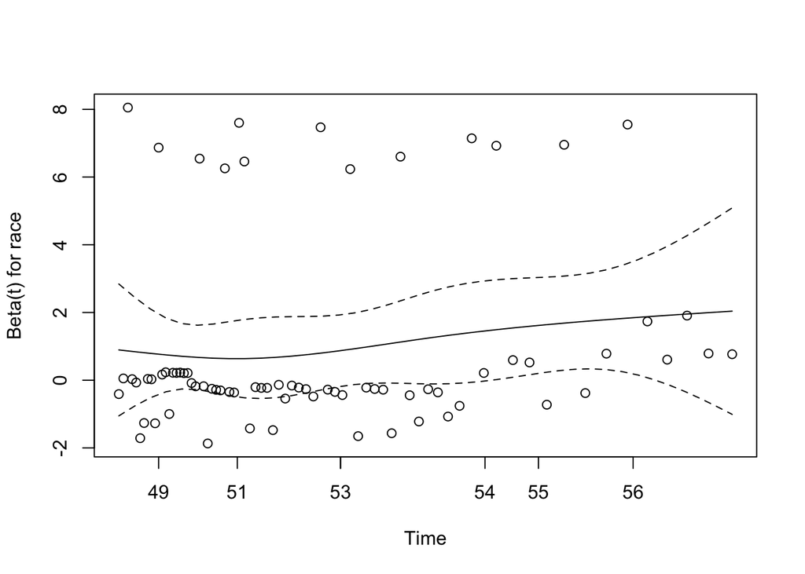

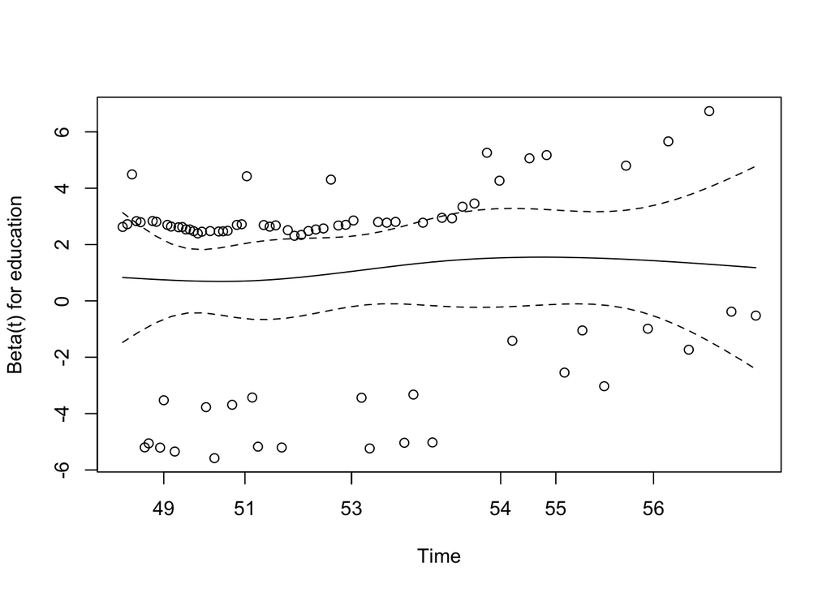

From the results, the assumption of PH holds well

Use the cox.zph function from the survival package. It results in two main things:

1. A hypothesis test of whether the effect of each covariate differs according to time, and a global test of all covariates at once. This is done by testiung for an interaction effect between the covariate and log(time). A significant p-value indicates that the proportional hazards assumption is violated
2. Plots of the Schoenfeld residuals Deviation from a zero-slope line is evidence that the proportional hazards assumption is violated